# 3a_basic_tools

## 1. **random**

### 1.1. random sample

1. seed: `set.seed(13579)`
2. `sample()`
   1. syntax  
      `sample(x, size, replace = FALSE, prob = NULL)` `sample.int(n, size = n, replace = FALSE, prob = NULL, useHash = (n > 1e+07 && !replace && is.null(prob) && size <= n/2))`
   2. usage

      ```
      # basics
      sample(c(1, 2, 3), size=2)
      sample(52, size = 5, replace=F)   # means sample from 1:52

      # without size param: means sample same num of (permutation)
      sample(10)  # permutation of 1:10 (since replace=F)

      # sample with probability
      sample(c(-1, 0, 1), size=2, prob=c(0.25, 0.5, 0.25))
      ```

### 1.2 Random distributions

1. Supported distributions

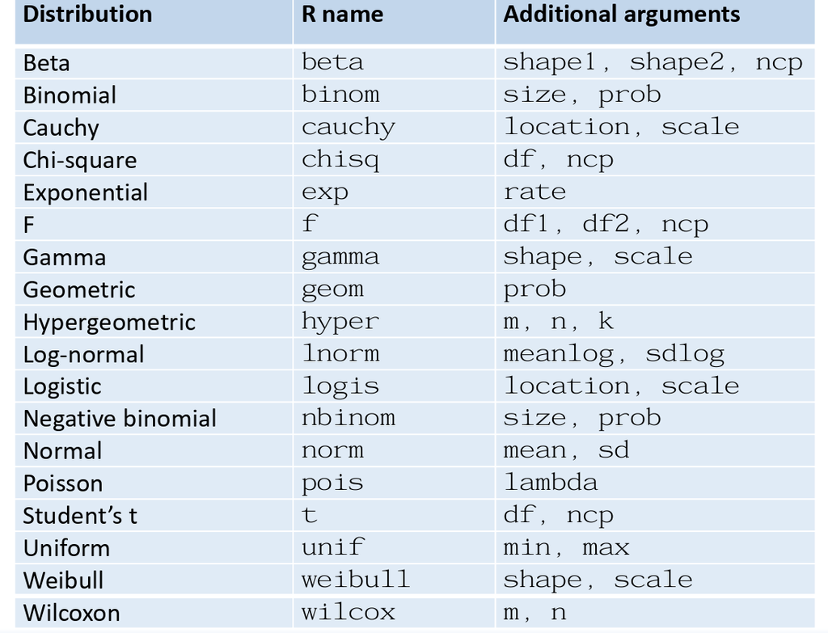

   1. Notes
      1. For uniform distribution, default min, max is 0, 1
      2. For normal distribution, default mean = 0, sd (sqrt(var)) = 1.  
         Also, when writing `N(1, 4)`, mean is 1, sd is sqrt(4) = 2!
2. Supported functions for these distributions  
   When using, just `<R_function_name><R_dist_name>`  
   Math def: Lec2 P22
   1. sample random number from the distribution:  
      R_function_name: `r` (random)  
      eg. `runif(n, min = 0, max = 1)`
   2. Probability density function (pdf) for discrete or Probability mass function (pmf) for continuous R_function_name: `d` (density) eg. `dnorm(seq(-4, 4, 0.1))`; `dbinom(0:20,size=20,prob=1/4)`
   3. Cumulative probability distribution function (cdf) R_function_name: `p` (probability) eg. `pnorm(1.96)`: P(x<1.96)
   4. Quantiles R_function_name: `q`  
      eg. `qnorm(0.25)`: x such that P(X<x) = 0.25  
      eg. `qnorm(0.5) = 0.00`

### 1.3 Examples

1. eg of random walk and plotting as time series  
   Lec2 P12-14
2. eg of Mont Carlo:  
   Intro Lec2 P16-17, 31-

## 2. **sorting**

1. sort `sort(x, decreasing = FALSE, ...)`

```
> sort(c(3, 12, 2, 1))
[1]  1  2  3 12
```

1. give sort order

```
# 2 methods both OK
> order(c(3, 12, 2, 1))
[1] 4 3 1 2

> sort.list(c(3, 12, 2, 1))
[1] 4 3 1 2
```

## 3. **vectorization**

`<CCLD>`: If is vectorization to vector, use `ifelse` or `vapply()`; If is matrix use `outer` to do mask first.

1. vector
2. use access expressions to modify

   ```
   v[v>0] <- v[v>0] * 2

   women$height[women$weight > 140]
   ```

3. `ifelse()` is a vectorization tool
4. generally `vapply()`
   1. idea: can use the vapply() function to vectorize the operation of a function that does not support vectorization.
   2. syntax

      ```
      vapply(X, FUN, FUN.VALUE, ...)
      ```

      1. X is vector, cannot be matrix
      2. FUN.VALUE specifies the output format numeric(1) indicating floating point format. Other possible output format includes: logical(1), integer(1), character(1)
   3. eg

      ```
      is.positive <- function(x) {
          if (x > 0) 1 else 0
      }

      vapply(x, is.positive, FUN.VALUE=numeric(1))
      ```

      1. note:  
         numeric(1) indicating floating point format. Other possible output format includes: logical(1), integer(1), character(1)
5. matrix, dataframe and other 2D f
   1. `outer`: Use it to generate masks. See matrix section
   2. `apply`: see section 2b 2.4

## 4. **Stats related**

1. basic stats values calculation: see section 2a 3.1.
2. Egs
   1. Critical value approach for testing if is the same distribution, at 95% significant level

      ```
      s1 <- sd(x)
      s2 <- sd(y)
      n1 <- length(x)
      n2 <- length(y)
      PooledSD <- sqrt(((n1-1)*s1^2+(n2-1)*s2^2)/(n1+n2-2))

      (t <- ((mean(x)-mean(y)))/(PooledSD*sqrt(1/n1+1/n2))) # t-statistic
      qt(.975,n1+n2-2)  # critical value (t_{\alpha/2})
      (abs(t) > qt(.975,n1+n2-2)) # if TRUE, we should reject H0
      ```